# 19100085_MuhammadAbdullah_Nasim_assignment3_q3

## Q3) Outlier Detection

Outlier detection (also known as '*anomaly detection*') is the process of finding observation points that are very distant from other observations. Such observation points are called outliers or anomalies. In this question, you will employ simple visualization and statistical techniques to find the outliers and then, you will apply outlier detection algorithms.

You will be using the same **"customer_segemntation"** dataset that was used in the Q1.

```python
import seaborn as sns
import numpy as np
import pandas as pd
import matplotlib.pyplot as plt
from scipy import stats
from scipy.cluster.vq import kmeans
from sklearn.neighbors import LocalOutlierFactor
from sklearn.cluster import DBSCAN
from matplotlib import cm
```

```python
#loading the dataset
cust_df = pd.read_csv("customer_segmentation.csv")
cust_df.head()
```

|  | Customer Id | Age | Edu | Years Employed | Income | Card Debt | Other Debt | Defaulted | Address | DebtIncomeRatio |
| --- | --- | --- | --- | --- | --- | --- | --- | --- | --- | --- |
| 0 | 1 | 41 | 2 | 6 | 19 | 0.124 | 1.073 | 0.0 | NBA001 | 6.3 |
| 1 | 2 | 47 | 1 | 26 | 100 | 4.582 | 8.218 | 0.0 | NBA021 | 12.8 |
| 2 | 3 | 33 | 2 | 10 | 57 | 6.111 | 5.802 | 1.0 | NBA013 | 20.9 |
| 3 | 4 | 29 | 2 | 4 | 19 | 0.681 | 0.516 | 0.0 | NBA009 | 6.3 |
| 4 | 5 | 47 | 1 | 31 | 253 | 9.308 | 8.908 | 0.0 | NBA008 | 7.2 |

```python
cust = cust_df.copy()
cust = cust.dropna()
print(cust.columns)
```

```
Index([u'Customer Id', u'Age', u'Edu', u'Years Employed', u'Income',
       u'Card Debt', u'Other Debt', u'Defaulted', u'Address',
       u'DebtIncomeRatio'],
      dtype='object')
```

### **Box-Plots**

Plot box-plots for "**Income**" and "**Card Debt**" attributes and comment on the results.

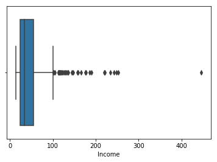

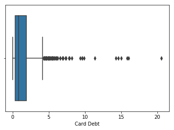

```python
#Write code here
sns.boxplot(x=cust['Income'])
plt.show()
sns.boxplot(x=cust['Card Debt'])
plt.show()
```

### **Scatter-plot**

Plot scatter-plot for **Income Vs DebtIncomeRatio**. Comment if it shows any outliers. Use matplotlib.pyplot library for scatter-plot.

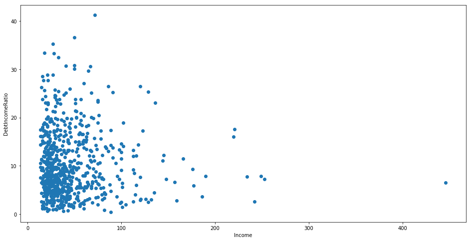

```python
#Write code here
fig, ax = plt.subplots(figsize=(16,8))
ax.scatter(cust['Income'], cust['DebtIncomeRatio'])
ax.set_xlabel('Income')
ax.set_ylabel('DebtIncomeRatio')
plt.show()

##Shows most values forming a cluster towards the left with outliers lyinng towards the far right.
```

### **Z_score**

Z-score tells how many standard deviations is a certain data point away from the mean. For **Age,Other_Debt and DebtIncomeRatio**, output the list of values that are identified as outliers on the basis of their z-scores.

```python
from scipy.stats import zscore
#Write code here
column1 = cust["Age"]
column2 = cust["Other Debt"]
column3 = cust["DebtIncomeRatio"]
xx=cust["Other Debt"].to_list()
Age = column1.copy()
Other_Debt= column2.copy()
DebtIR=column3.copy()

z = np.abs(stats.zscore(Age))
z_Age_Indexes = np.where(z > 2 )
z1 = np.abs(stats.zscore(Other_Debt))
z_OtherDebt_Indexes = np.where(z1 > 3 )
z2 = np.abs(stats.zscore(DebtIR))
z_DebtIR_Indexes = np.where(z2 > 3 )
for i in z_Age_Indexes:
    print(Age.iloc[i])
for i in z_OtherDebt_Indexes:
    print(Other_Debt.iloc[i])
for i in z_DebtIR_Indexes:
    print(DebtIR.iloc[i])
```

```
175    53
179    52
197    52
205    51
254    51
265    55
335    52
339    53
368    51
373    53
427    54
438    55
443    51
454    51
513    54
```

[output cut: 36 more lines]

- **What z-score threshold did you use to detect the outliers and why?** A Z-score of 2 was used for age as the values showed a very small range. The standard Z value of 3 was used for the other two variables.

### *IQR*

For **Age,Other_Debt and DebtIncomeRatio**, output the list of values that are identified as outliers on the basis of their IQR values.

For this, calculate the first (q1) and third quartile (q3). An outlier is then a data point that lies outside the interquartile range. That is:

- *Lower outlier= Q1 - (k x IQR)*
- *Higher outlier= Q3 + (k x IQR)*

Choose an appropriate 'k' for this part.

```python
#Write code here
Q1_A = Age.quantile(0.25)
Q3_A = Age.quantile(0.75)
IQR_A = Q3_A - Q1_A
Age1 = cust['Age'].to_list()

Q1_O = Other_Debt.quantile(0.25)
Q3_O = Other_Debt.quantile(0.75)
IQR_O = Q3_O - Q1_O
OD1 = cust["Other Debt"].to_list()

Q1_DR = DebtIR.quantile(0.25)
Q3_DR = DebtIR.quantile(0.75)
IQR_DR = Q3_DR - Q1_DR
DebtIR1 = cust["DebtIncomeRatio"].to_list()

OutAge=[]
OutOtherDebt=[]
OutDebtIR=[]
for i in Age1:
    if (i < (Q1_A - (1.5 * IQR_A))) or (i > (Q3_A + (1.5 * IQR_A))):
        OutAge.append(i)
for i in OD1:
    if (i < (Q1_O - (1.5 * IQR_O))) or (i > (Q3_O + (1.5 * IQR_O))):
        OutOtherDebt.append(i)
for i in DebtIR1:
    if (i < (Q1_DR - (1.5 * IQR_DR))) or (i > (Q3_DR + (1.5 * IQR_DR))):
        OutDebtIR.append(i)


print("IQR for Age = ",IQR_A)
print("IQR for Other Debt = ",IQR_O)
print("IQR for DebtIR = ",IQR_DR)
print("Age Outliers:")
print(OutAge)
print("\n")
print("OtherDebt Outliers:")
print(OutOtherDebt)
print("\n")
print("DebtIR Outliers:")
print(OutDebtIR)
```

```
('IQR for Age = ', 11.0)
('IQR for Other Debt = ', 2.8792500000000003)
('IQR for DebtIR = ', 9.125)
Age Outliers:
[]


OtherDebt Outliers:
[8.908, 18.257, 10.184, 9.555, 9.459, 10.754000000000001, 14.453, 15.405, 11.874, 9.251, 12.075999999999999, 23.104, 8.6, 9.044, 9.737, 11.894, 20.616, 11.724, 11.042, 17.185, 13.050999999999998, 12.659, 9.591000000000001, 8.502, 15.149000000000001, 17.799, 18.269000000000002, 9.391, 12.714, 14.7190…


DebtIR Outliers:
[32.5, 29.7, 30.1, 28.9, 28.5, 30.7, 28.9, 41.3, 30.6, 35.3, 33.3, 36.6, 30.8, 33.4]
```

- **What k-value did you use to detect the outliers and why?** 1.5 was chosen as the K value. An IQR lower than this resulted in a very small confidence interval that covered a very small percentile range. A value larger than this covered almost the whole dataset. 1.5 represents the range from the 16th to the 84th percentile which is an ample interval along with a sufficient confidence interval (about 70%)
- **Which parameter (IQR or Z-score) is better outlier detection? Give reason.**

### **Outlier Detection using LOC (Local Outlier Factor)**

LOF uses density-based outlier detection to identify local outliers. An anomaly score is assigned to each sample which measures the local deviation of density of a this sample with respect to its neighbors.

**1.** Tranform the features by scaling them to a given range(e.g. 0-1):

```python
from sklearn import preprocessing
from sklearn.preprocessing import MinMaxScaler
#Write your code here
### Code here
new = cust.filter(['Age','Other Debt','DebtIncomeRatio'], axis=1)
scaler_minmax = MinMaxScaler()
new_scaled = scaler_minmax.fit_transform(new)
new1 = pd.DataFrame(new_scaled)
new1.columns = ['Age', 'Other Debt', 'DebtIncomeRatio']
new1 #after normalization
X = new1.iloc[:,0:2] #for LOC and IF
```

**2.** Implement LOC algorithm using sklearn. Choose the parameters that will be passed into the function:

```python
#Write your code here
model = LocalOutlierFactor(n_neighbors=30, metric='minkowski',contamination=0.1)
model.fit_predict(new1)
scores_pred = model.negative_outlier_factor_
threshold = stats.scoreatpercentile(scores_pred, 5) #assuming 5% for outlier fraction
labels = [('anomaly' if x<threshold else 'normal') for x in scores_pred]
```

Run LOC algorithm multiple times with different values for the '**n_neighbors** 'paramater.

```python
model1 = LocalOutlierFactor(n_neighbors=10, metric='minkowski',contamination=0.1)
model1.fit_predict(new1)
scores_pred = model1.negative_outlier_factor_
threshold = stats.scoreatpercentile(scores_pred, 5) #assuming 5% for outlier fraction
print(threshold)
labels1 = [('anomaly' if x<threshold else 'normal') for x in scores_pred]
count = 0
for i in labels1:
    if i == 'anomaly':
        count = count + 1
print("For n=10, anomaly count = ",count)

model2 = LocalOutlierFactor(n_neighbors=20, metric='minkowski',contamination=0.1)
model2.fit_predict(new1)
scores_pred = model2.negative_outlier_factor_
threshold = stats.scoreatpercentile(scores_pred, 5) #assuming 5% for outlier fraction
labels2 = [('anomaly' if x<threshold else 'normal') for x in scores_pred]
count1 = 0
print(threshold)

for i in labels2:
    if i == 'anomaly':
        count1 = count1 + 1
print("For n=20, anomaly count = ",count1)

model3 = LocalOutlierFactor(n_neighbors=30, metric='minkowski',contamination=0.1)
model3.fit_predict(new1)
scores_pred = model3.negative_outlier_factor_
threshold = stats.scoreatpercentile(scores_pred, 5) #assuming 5% for outlier fraction
labels2 = [('anomaly' if x<threshold else 'normal') for x in scores_pred]
count2=0
print(threshold)
for i in labels2:
    if i == 'anomaly':
        count2 = count2 + 1
print("For n=30, anomaly count = ",count2)
```

```
-1.3364723858594563
('For n=10, anomaly count = ', 35)
-1.34794552618368
('For n=20, anomaly count = ', 35)
-1.3733439565059764
('For n=30, anomaly count = ', 35)
```

- **How did the results of LOC alogrithm vary by changing the value of 'n_neighbors'? What parameter value you ended up choosing and why?**

**3.** Visualize the results using this function. You may also implement your own visualization function.

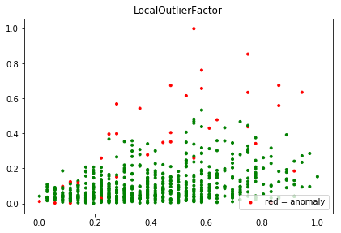

```python
fig = plt.figure(figsize=(15,15))
def plot_model(labels, alg_name):
    ax = fig.add_subplot(3,2,1)
    color_code = {'anomaly':'red', 'normal':'green'}
    colors = [color_code[x] for x in labels]

    ax.scatter(X.iloc[:,0], X.iloc[:,1], color=colors, marker='.', label='red = anomaly')
    ax.legend(loc="lower right")

    leg = plt.gca().get_legend()
    leg.legendHandles[0].set_color('red')

    ax.set_title(alg_name)

plot_model(labels, 'LocalOutlierFactor')
```

### **Isolation Forest**

Isolation Forest is an outlier detection algoritm that is based on the Decision Trees. It spearates the outliers by randomly selecting a certain attribute and then randomly selecting a split value between the max and min values of this feature.

**1.** Implement Isolation Forest algorithm using sklearn. Choose the parameters that will be passed into the function:

```python
#Write your code here
from sklearn.ensemble import IsolationForest
model = IsolationForest(max_samples = 100, behaviour="new", contamination=0.1).fit(X)
scores_pred = model.decision_function(X)
threshold = stats.scoreatpercentile(scores_pred, 5)
labels = [('anomaly' if x<threshold else 'normal') for x in scores_pred]

model1 = IsolationForest(max_samples = 50, behaviour="new", contamination=0.1).fit(X)
scores_pred = model1.decision_function(X)
threshold = stats.scoreatpercentile(scores_pred, 5)
labels1 = [('anomaly' if x<threshold else 'normal') for x in scores_pred]
```

- **What value did you use for the 'max_samples'?** Max sample value was 100.

**2.** Visualize the results using this function. You may also implement your own visualization function.

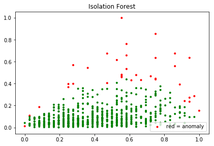

```python
fig = plt.figure(figsize=(15,15))
plot_model(labels, 'Isolation Forest')
```

- **Compare the results from both LOC and Isolation Forest:**

*Comparison:* Isolation forest showed the same trends with outliers as with LOC but because of using a different metric, the Isolation forest showed a higher number of outliers towards the data points with larger normalized values but smaller Isolation scores. LOC considered larger normalized values with lower LOC scores to be normal values.